# ArchFlow

Estefania Calparsoro

2021-07-01

##Summary

The Archdata package is a CRAN package, providing several types of data that are typically used in archaeological research.

In this particular R Script we will be using the RBPottery dataset.

## Dataset Description

The RBPottery which is a a dataset containing results of chemical analyses of 48 specimens of Romano-British pottery from 5 sites in 3 regions.

- Kiln Kiln: Gloucester, Llanedeyrn, Caldicot, Islands Thorns, and Ashley Rails
- Region Region: Gloucester, Wales, and New Forest
- Al<sub>2</sub>O<sub>3</sub> Percentage aluminum trioxide
- Fe<sub>2</sub>O<sub>3</sub> Percentage Iron trioxide
- MgO Percentage magnesium oxide
- CaO Percentage calcium oxide
- Na<sub>2</sub>O Percentage sodium oxide
- K<sub>2</sub>O Percentage potassium oxide
- TiO<sub>2</sub> Percentage titanium dioxide
- MnO Percentage manganese oxide
- BaO Percentage barium oxide

**Details**:

Results of chemical analyses of 48 specimens of Romano-British pottery published by Tubb, et al. (1980). The numbers are the percentage metal oxide. “Kiln” indicates at which kiln site the pottery was found. The kiln sites come from three regions (1=Gloucester, (2=Llanedeyrn, 3=Caldicot), (4=Islands Thorns, 5=Ashley Rails)). The data were scanned from Table 2.2 in Baxter (2003, p. 21) and preserve three probable typographical errors in the original publication. Those errors are the values for TiO<sub>2</sub> in line 4 (sample GA4), for MnO in line 35 (sample C13), and for K<sub>2</sub>O in line 36 (sample C14). Versions of these data are also available as Pottery in package car, pottery in package HSAUR, and Pottery2 in package heplots.

**Source**:

David L. Carlson and Georg Roth (2016). archdata: Example Datasets from Archaeological Research. R package version 1.1. https://CRAN.R-project.org/package=archdata

**References**

Baxter, M. J. 2003. Statistics in Archaeology. Arnold.

Tubb, A., A. J. Parker, and G. Nickless. 1980. The Analysis of Romano-British Pottery by Atomic Absorption Spectrophotometry. Archaeometry 22: 153-71.

### Install ArchFlow package

```r
if(!require(devtools)) install.packages("devtools",repos = "http://cran.us.r-project.org")
install_github("esteful/ArchFlow")
```

```
#> Skipping install of 'ArchFlow' from a github remote, the SHA1 (eab0170d) has not changed since last install.
#>   Use `force = TRUE` to force installation
```

```r
library("ArchFlow")
```

### Load RBPottery from Archdata package (example data). Alternatively, import csv

```r
if(!require(archdata)) install.packages("archdata",repos = "http://cran.us.r-project.org")
library("archdata")
```

```r
  data(RBPottery)
  knitr::kable(RBPottery)
```

| ID | Kiln | Region | Al2O3 | Fe2O3 | MgO | CaO | Na2O | K2O | TiO2 | MnO | BaO |
| --- | --- | --- | --- | --- | --- | --- | --- | --- | --- | --- | --- |
| GA1 | Gloucester | Gloucester | 18.8 | 9.52 | 2.00 | 0.79 | 0.40 | 3.20 | 1.01 | 0.077 | 0.015 |
| GA2 | Gloucester | Gloucester | 16.9 | 7.33 | 1.65 | 0.84 | 0.40 | 3.05 | 0.99 | 0.067 | 0.018 |
| GA3 | Gloucester | Gloucester | 18.2 | 7.64 | 1.82 | 0.77 | 0.40 | 3.07 | 0.98 | 0.087 | 0.014 |
| GA4 | Gloucester | Gloucester | 17.4 | 7.48 | 1.71 | 1.01 | 0.40 | 3.16 | 0.03 | 0.084 | 0.017 |
| GA5 | Gloucester | Gloucester | 16.9 | 7.29 | 1.56 | 0.76 | 0.40 | 3.05 | 1.00 | 0.063 | 0.019 |
| GB1 | Gloucester | Gloucester | 17.8 | 7.24 | 1.83 | 0.92 | 0.43 | 3.12 | 0.93 | 0.061 | 0.019 |
| GB2 | Gloucester | Gloucester | 18.8 | 7.45 | 2.06 | 0.87 | 0.25 | 3.26 | 0.98 | 0.072 | 0.017 |
| GB3 | Gloucester | Gloucester | 16.5 | 7.05 | 1.81 | 1.73 | 0.33 | 3.20 | 0.95 | 0.066 | 0.019 |
| GB4 | Gloucester | Gloucester | 18.0 | 7.42 | 2.06 | 1.00 | 0.28 | 3.37 | 0.96 | 0.072 | 0.017 |
| GB5 | Gloucester | Gloucester | 15.8 | 7.15 | 1.62 | 0.71 | 0.38 | 3.25 | 0.93 | 0.062 | 0.017 |
| GC1 | Gloucester | Gloucester | 14.6 | 6.87 | 1.67 | 0.76 | 0.33 | 3.06 | 0.91 | 0.055 | 0.012 |
| GC2 | Gloucester | Gloucester | 13.7 | 5.83 | 1.50 | 0.66 | 0.13 | 2.25 | 0.75 | 0.034 | 0.012 |
| GC3 | Gloucester | Gloucester | 14.6 | 6.76 | 1.63 | 1.48 | 0.20 | 3.02 | 0.87 | 0.055 | 0.016 |
| GC4 | Gloucester | Gloucester | 14.8 | 7.07 | 1.62 | 1.44 | 0.24 | 3.03 | 0.86 | 0.080 | 0.016 |
| GD1 | Gloucester | Gloucester | 17.1 | 7.79 | 1.99 | 0.83 | 0.46 | 3.13 | 0.93 | 0.090 | 0.020 |
| GD2 | Gloucester | Gloucester | 16.8 | 7.86 | 1.86 | 0.84 | 0.46 | 2.93 | 0.94 | 0.094 | 0.020 |
| GD3 | Gloucester | Gloucester | 15.8 | 7.65 | 1.94 | 0.81 | 0.83 | 3.33 | 0.96 | 0.112 | 0.019 |
| GD4 | Gloucester | Gloucester | 18.6 | 7.85 | 2.33 | 0.87 | 0.38 | 3.17 | 0.98 | 0.081 | 0.018 |
| GD5 | Gloucester | Gloucester | 16.9 | 7.87 | 1.83 | 1.31 | 0.53 | 3.09 | 0.95 | 0.092 | 0.023 |
| GE1 | Gloucester | Gloucester | 18.9 | 7.58 | 2.05 | 0.83 | 0.13 | 3.29 | 0.98 | 0.072 | 0.015 |
| GE2 | Gloucester | Gloucester | 18.0 | 7.50 | 1.94 | 0.69 | 0.12 | 3.14 | 0.93 | 0.035 | 0.017 |
| GE3 | Gloucester | Gloucester | 17.8 | 7.28 | 1.92 | 0.81 | 0.18 | 3.15 | 0.90 | 0.067 | 0.017 |
| C01 | Llanedeyrn | Wales | 14.4 | 7.00 | 4.30 | 0.15 | 0.51 | 4.25 | 0.79 | 0.160 | 0.019 |
| CO2 | Llanedeyrn | Wales | 13.8 | 7.08 | 3.43 | 0.12 | 0.17 | 4.14 | 0.77 | 0.144 | 0.020 |
| CO3 | Llanedeyrn | Wales | 14.6 | 7.09 | 3.88 | 0.13 | 0.20 | 4.36 | 0.81 | 0.124 | 0.019 |
| C04 | Llanedeyrn | Wales | 11.5 | 6.37 | 5.64 | 0.16 | 0.14 | 3.89 | 0.69 | 0.087 | 0.009 |
| CO5 | Llanedeyrn | Wales | 13.8 | 7.06 | 5.34 | 0.20 | 0.20 | 4.31 | 0.71 | 0.101 | 0.021 |
| C06 | Llanedeyrn | Wales | 10.9 | 6.26 | 3.47 | 0.17 | 0.22 | 3.40 | 0.66 | 0.109 | 0.010 |
| C07 | Llanedeyrn | Wales | 10.1 | 4.26 | 4.26 | 0.20 | 0.18 | 3.32 | 0.59 | 0.149 | 0.017 |
| C08 | Llanedeyrn | Wales | 11.6 | 5.78 | 5.91 | 0.18 | 0.16 | 3.70 | 0.65 | 0.082 | 0.015 |
| C09 | Llanedeyrn | Wales | 11.1 | 5.49 | 4.52 | 0.29 | 0.30 | 4.03 | 0.63 | 0.080 | 0.016 |
| C10 | Llanedeyrn | Wales | 13.4 | 6.92 | 7.23 | 0.28 | 0.20 | 4.54 | 0.69 | 0.163 | 0.017 |
| C11 | Llanedeyrn | Wales | 12.4 | 6.13 | 5.69 | 0.22 | 0.54 | 4.65 | 0.70 | 0.159 | 0.015 |
| C12 | Llanedeyrn | Wales | 13.1 | 6.64 | 5.51 | 0.31 | 0.24 | 4.89 | 0.72 | 0.094 | 0.017 |
| C13 | Llanedeyrn | Wales | 12.7 | 6.69 | 4.45 | 0.20 | 0.22 | 4.70 | 0.73 | 0.394 | 0.024 |
| C14 | Llanedeyrn | Wales | 12.5 | 6.44 | 3.94 | 0.22 | 0.23 | 0.81 | 0.75 | 0.177 | 0.019 |
| GO1 | Caldicot | Wales | 11.6 | 5.39 | 3.77 | 0.29 | 0.06 | 4.51 | 0.56 | 0.110 | 0.015 |
| G02 | Caldicot | Wales | 11.8 | 5.44 | 3.94 | 0.30 | 0.04 | 4.64 | 0.59 | 0.085 | 0.013 |
| T11 | Islands Thorns | New Forest | 18.3 | 1.28 | 0.67 | 0.03 | 0.03 | 1.96 | 0.65 | 0.001 | 0.014 |
| T12 | Islands Thorns | New Forest | 15.8 | 2.39 | 0.63 | 0.01 | 0.04 | 1.94 | 1.29 | 0.001 | 0.014 |
| T13 | Islands Thorns | New Forest | 18.0 | 1.50 | 0.67 | 0.01 | 0.06 | 2.11 | 0.92 | 0.001 | 0.016 |
| T14 | Islands Thorns | New Forest | 18.0 | 1.88 | 0.68 | 0.01 | 0.04 | 2.00 | 1.11 | 0.006 | 0.022 |
| T16 | Islands Thorns | New Forest | 20.8 | 1.51 | 0.72 | 0.07 | 0.10 | 2.37 | 1.26 | 0.002 | 0.016 |
| A11 | Ashley Rails | New Forest | 17.7 | 1.12 | 0.56 | 0.06 | 0.06 | 2.06 | 0.79 | 0.001 | 0.013 |
| Al2 | Ashley Rails | New Forest | 18.3 | 1.14 | 0.67 | 0.06 | 0.05 | 2.11 | 0.89 | 0.006 | 0.019 |
| A16 | Ashley Rails | New Forest | 16.7 | 0.92 | 0.53 | 0.01 | 0.05 | 1.76 | 0.91 | 0.004 | 0.013 |
| A18 | Ashley Rails | New Forest | 14.8 | 2.74 | 0.67 | 0.03 | 0.05 | 2.15 | 1.34 | 0.003 | 0.015 |
| A26 | Ashley Rails | New Forest | 19.1 | 1.64 | 0.60 | 0.10 | 0.03 | 1.75 | 1.04 | 0.007 | 0.018 |

###Declare df_raw and df_chem, and set the row.names

```r
  row.names(RBPottery) <- RBPottery[,1]
  df_raw <- RBPottery  #we are calling to the whole dataset
  df_chem <- RBPottery[,-c(1:3)] #ignore all the columns containing categorical data, 9 in this case.
```

###Check the structure of the new dataset (skip if desired)

```r
  str(df_raw)
```

```
#> 'data.frame':    48 obs. of  12 variables:
#>  $ ID    : chr  "GA1" "GA2" "GA3" "GA4" ...
#>  $ Kiln  : Factor w/ 5 levels "Gloucester","Llanedeyrn",..: 1 1 1 1 1 1 1 1 1 1 ...
#>  $ Region: Factor w/ 3 levels "Gloucester","Wales",..: 1 1 1 1 1 1 1 1 1 1 ...
#>  $ Al2O3 : num  18.8 16.9 18.2 17.4 16.9 17.8 18.8 16.5 18 15.8 ...
#>  $ Fe2O3 : num  9.52 7.33 7.64 7.48 7.29 7.24 7.45 7.05 7.42 7.15 ...
#>  $ MgO   : num  2 1.65 1.82 1.71 1.56 1.83 2.06 1.81 2.06 1.62 ...
#>  $ CaO   : num  0.79 0.84 0.77 1.01 0.76 0.92 0.87 1.73 1 0.71 ...
#>  $ Na2O  : num  0.4 0.4 0.4 0.4 0.4 0.43 0.25 0.33 0.28 0.38 ...
#>  $ K2O   : num  3.2 3.05 3.07 3.16 3.05 3.12 3.26 3.2 3.37 3.25 ...
#>  $ TiO2  : num  1.01 0.99 0.98 0.03 1 0.93 0.98 0.95 0.96 0.93 ...
#>  $ MnO   : num  0.077 0.067 0.087 0.084 0.063 0.061 0.072 0.066 0.072 0.062 ...
#>  $ BaO   : num  0.015 0.018 0.014 0.017 0.019 0.019 0.017 0.019 0.017 0.017 ...
```

In df_chem only integers (int) or numerical (num). Num class contain decimals

```r
  str(df_chem)
```

```
#> 'data.frame':    48 obs. of  9 variables:
#>  $ Al2O3: num  18.8 16.9 18.2 17.4 16.9 17.8 18.8 16.5 18 15.8 ...
#>  $ Fe2O3: num  9.52 7.33 7.64 7.48 7.29 7.24 7.45 7.05 7.42 7.15 ...
#>  $ MgO  : num  2 1.65 1.82 1.71 1.56 1.83 2.06 1.81 2.06 1.62 ...
#>  $ CaO  : num  0.79 0.84 0.77 1.01 0.76 0.92 0.87 1.73 1 0.71 ...
#>  $ Na2O : num  0.4 0.4 0.4 0.4 0.4 0.43 0.25 0.33 0.28 0.38 ...
#>  $ K2O  : num  3.2 3.05 3.07 3.16 3.05 3.12 3.26 3.2 3.37 3.25 ...
#>  $ TiO2 : num  1.01 0.99 0.98 0.03 1 0.93 0.98 0.95 0.96 0.93 ...
#>  $ MnO  : num  0.077 0.067 0.087 0.084 0.063 0.061 0.072 0.066 0.072 0.062 ...
#>  $ BaO  : num  0.015 0.018 0.014 0.017 0.019 0.019 0.017 0.019 0.017 0.017 ...
```

###Boxplots with the distribution of the chemical elements

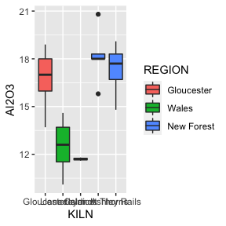

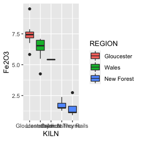

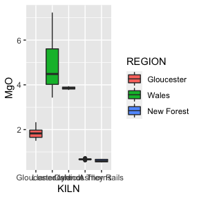

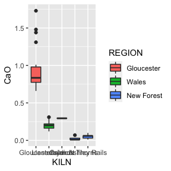

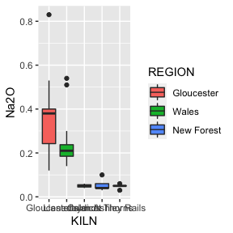

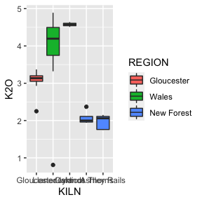

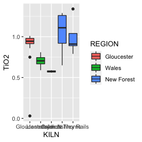

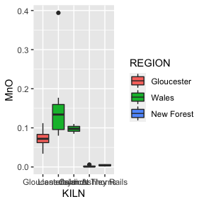

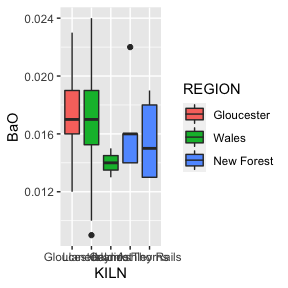

```r
  for (i in 1:ncol(df_chem)){
  .datt <- data.frame(REGION=df_raw$Region, i= df_chem[,i], KILN=df_raw$Kiln)
  plot(ggplot2::ggplot(.datt, ggplot2::aes(x= KILN, y = i, fill=REGION)) + ggplot2::geom_boxplot() + ggplot2::ylab(colnames(df_chem)[i]))
  }
```

###Create categories based on the calcium content or any other condition (optional)

```r
  df_raw$Calcium <- c() #Create the desired column

  "Low-Calcareous(CaO<6%)" ->   df_raw$Calcium[df_raw$CaO < 6]
  "Calcareous (6%<CaO<20%)" ->       df_raw$Calcium[df_raw$CaO> 6]
  "High Calcareous (CaO>%20)" -> df_raw$Calcium[df_raw$CaO > 20]

  df_raw$Calcium <- as.factor(df_raw$Calcium)  #bring back to factors
```

We might want to have a glance at which is the calcium content of the samples (two options)

```r
df_raw[,c("CaO", "Calcium")]
```

```
#>      CaO                Calcium
#> GA1 0.79 Low-Calcareous(CaO<6%)
#> GA2 0.84 Low-Calcareous(CaO<6%)
#> GA3 0.77 Low-Calcareous(CaO<6%)
#> GA4 1.01 Low-Calcareous(CaO<6%)
#> GA5 0.76 Low-Calcareous(CaO<6%)
#> GB1 0.92 Low-Calcareous(CaO<6%)
#> GB2 0.87 Low-Calcareous(CaO<6%)
#> GB3 1.73 Low-Calcareous(CaO<6%)
#> GB4 1.00 Low-Calcareous(CaO<6%)
#> GB5 0.71 Low-Calcareous(CaO<6%)
#> GC1 0.76 Low-Calcareous(CaO<6%)
#> GC2 0.66 Low-Calcareous(CaO<6%)
#> GC3 1.48 Low-Calcareous(CaO<6%)
#> GC4 1.44 Low-Calcareous(CaO<6%)
#> GD1 0.83 Low-Calcareous(CaO<6%)
#> GD2 0.84 Low-Calcareous(CaO<6%)
#> GD3 0.81 Low-Calcareous(CaO<6%)
#> GD4 0.87 Low-Calcareous(CaO<6%)
#> GD5 1.31 Low-Calcareous(CaO<6%)
#> GE1 0.83 Low-Calcareous(CaO<6%)
#> GE2 0.69 Low-Calcareous(CaO<6%)
#> GE3 0.81 Low-Calcareous(CaO<6%)
#> C01 0.15 Low-Calcareous(CaO<6%)
#> CO2 0.12 Low-Calcareous(CaO<6%)
#> CO3 0.13 Low-Calcareous(CaO<6%)
#> C04 0.16 Low-Calcareous(CaO<6%)
#> CO5 0.20 Low-Calcareous(CaO<6%)
#> C06 0.17 Low-Calcareous(CaO<6%)
#> C07 0.20 Low-Calcareous(CaO<6%)
#> C08 0.18 Low-Calcareous(CaO<6%)
#> C09 0.29 Low-Calcareous(CaO<6%)
#> C10 0.28 Low-Calcareous(CaO<6%)
#> C11 0.22 Low-Calcareous(CaO<6%)
#> C12 0.31 Low-Calcareous(CaO<6%)
#> C13 0.20 Low-Calcareous(CaO<6%)
#> C14 0.22 Low-Calcareous(CaO<6%)
#> GO1 0.29 Low-Calcareous(CaO<6%)
#> G02 0.30 Low-Calcareous(CaO<6%)
#> T11 0.03 Low-Calcareous(CaO<6%)
#> T12 0.01 Low-Calcareous(CaO<6%)
#> T13 0.01 Low-Calcareous(CaO<6%)
#> T14 0.01 Low-Calcareous(CaO<6%)
#> T16 0.07 Low-Calcareous(CaO<6%)
#> A11 0.06 Low-Calcareous(CaO<6%)
#> Al2 0.06 Low-Calcareous(CaO<6%)
#> A16 0.01 Low-Calcareous(CaO<6%)
#> A18 0.03 Low-Calcareous(CaO<6%)
#> A26 0.10 Low-Calcareous(CaO<6%)
```

```r
#select(df_raw,c(CaO,Calcareous))
```

##Applying statistics to the dataset

###Variation Matrix

```r
arch_varmat(df_chem)
```

```
#> %Values of vt/t.i (in Buxeda's notation).
#>
#>
#>   %Maximum determines variable to use as divisor in subsequent log-ratio transformation.
#>
#>
#>  % 0.5587909 0.9061 0.6586535 0.3133616 0.6429078 0.7281169 0.4332269 0.2787468 0.6358259
#>
#> %Maximum value :  0.9061
#> %Variable :  2
#>             Al2O3     Fe2O3       MgO        CaO      Na2O       K2O      TiO2
#> Al2O3  0.00000000 0.5130187 0.7625391  2.0777534 0.8358279 0.1946776 0.2689208
#> Fe2O3  0.51301874 0.0000000 0.2800250  0.9492262 0.2934747 0.2792781 0.7934730
#> MgO    0.76253913 0.2800250 0.0000000  1.7316452 0.6674436 0.3110356 0.9927027
#> CaO    2.07775336 0.9492262 1.7316452  0.0000000 0.9480985 1.7801891 2.5579971
#> Na2O   0.83582792 0.2934747 0.6674436  0.9480985 0.0000000 0.6434720 1.1726813
#> K2O    0.19467764 0.2792781 0.3110356  1.7801891 0.6434720 0.0000000 0.4524119
#> TiO2   0.26892077 0.7934730 0.9927027  2.5579971 1.1726813 0.4524119 0.0000000
#> MnO    2.80441987 1.1101259 1.0598289  1.3386072 1.2455265 1.9550258 3.1479743
#> BaO    0.05256085 0.4126138 0.5659023  2.0079214 0.7206359 0.1472181 0.3001303
#> t.i    7.50971828 4.6312355 6.3711225 13.3914380 6.5271603 5.7633082 9.6862914
#> vt/t.i 0.55879091 0.9061000 0.6586535  0.3133616 0.6429078 0.7281169 0.4332269
#> r v,t  0.86883527 0.9746516 0.8527275  0.1260746 0.8427641 0.9193259 0.9127645
#> vt     4.19636229 0.0000000 0.0000000  0.0000000 0.0000000 0.0000000 0.0000000
#>               MnO        BaO
#> Al2O3   2.8044199 0.05256085
#> Fe2O3   1.1101259 0.41261381
#> MgO     1.0598289 0.56590230
#> CaO     1.3386072 2.00792138
#> Na2O    1.2455265 0.72063586
#> K2O     1.9550258 0.14721809
#> TiO2    3.1479743 0.30013031
#> MnO     0.0000000 2.39287790
#> BaO     2.3928779 0.00000000
#> t.i    15.0543864 6.59986049
#> vt/t.i  0.2787468 0.63582591
#> r v,t   0.1732152 0.87521633
#> vt      0.0000000 0.00000000
```

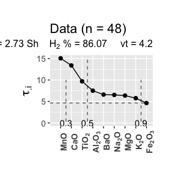

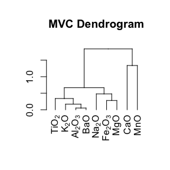

```
#> $MVC
#>             Al2O3     Fe2O3       MgO        CaO      Na2O       K2O      TiO2
#> Al2O3  0.00000000 0.5130187 0.7625391  2.0777534 0.8358279 0.1946776 0.2689208
#> Fe2O3  0.51301874 0.0000000 0.2800250  0.9492262 0.2934747 0.2792781 0.7934730
#> MgO    0.76253913 0.2800250 0.0000000  1.7316452 0.6674436 0.3110356 0.9927027
#> CaO    2.07775336 0.9492262 1.7316452  0.0000000 0.9480985 1.7801891 2.5579971
#> Na2O   0.83582792 0.2934747 0.6674436  0.9480985 0.0000000 0.6434720 1.1726813
#> K2O    0.19467764 0.2792781 0.3110356  1.7801891 0.6434720 0.0000000 0.4524119
#> TiO2   0.26892077 0.7934730 0.9927027  2.5579971 1.1726813 0.4524119 0.0000000
#> MnO    2.80441987 1.1101259 1.0598289  1.3386072 1.2455265 1.9550258 3.1479743
#> BaO    0.05256085 0.4126138 0.5659023  2.0079214 0.7206359 0.1472181 0.3001303
#> t.i    7.50971828 4.6312355 6.3711225 13.3914380 6.5271603 5.7633082 9.6862914
#> vt/t.i 0.55879091 0.9061000 0.6586535  0.3133616 0.6429078 0.7281169 0.4332269
#> r v,t  0.86883527 0.9746516 0.8527275  0.1260746 0.8427641 0.9193259 0.9127645
#> vt     4.19636229 0.0000000 0.0000000  0.0000000 0.0000000 0.0000000 0.0000000
#>               MnO        BaO
#> Al2O3   2.8044199 0.05256085
#> Fe2O3   1.1101259 0.41261381
#> MgO     1.0598289 0.56590230
#> CaO     1.3386072 2.00792138
#> Na2O    1.2455265 0.72063586
#> K2O     1.9550258 0.14721809
#> TiO2    3.1479743 0.30013031
#> MnO     0.0000000 2.39287790
#> BaO     2.3928779 0.00000000
#> t.i    15.0543864 6.59986049
#> vt/t.i  0.2787468 0.63582591
#> r v,t   0.1732152 0.87521633
#> vt      0.0000000 0.00000000
#>
#> $Entropia
#> NULL
#>
#> $Probabilitat
#> NULL
#>
#> $Signary
#>       V1 V2 V3 V4 V5 V6 V7 V8
#> Al2O3  1  0  1  0  1  0  1  1
#> Fe2O3  1  0 -1  1  0  1  0  0
```

[output cut: 116 more lines]

```
#> C14 -0.4148397 4.588448
#> GO1 -1.9437903 4.702762
#> G02 -2.0184347 4.816037
#> T11 -1.1054081 5.073915
#> T12 -1.1570018 4.970047
#> T13 -1.1178535 4.967806
#> T14 -0.9441295 4.742625
#> T16 -1.1537070 5.070040
#> A11 -1.1899022 5.102745
#> Al2 -1.0409479 4.857977
#> A16 -1.0851341 5.061622
#> A18 -1.2394474 4.875029
#> A26 -0.8928091 4.926464
#> attr(,"class")
#> [1] "rmult"
```

```r
arch_evenness(df_chem)
```

###Scatter plot Matrix

```r
  #select this with the variables to use
  vars <- c("MnO","CaO","Na2O", "TiO2","BaO", "Al2O3")

  #alr conversion
  compositions::alr(df_chem,ivar = 2)-> df_alr
  cbind(df_raw[,1:3],df_alr) -> df_alr

  arch_scatter_matrix(df_raw=df_alr, vars, color = "Region", shape = "Kiln", title= "RBPottery")
```

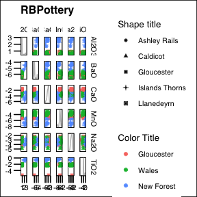

```r
  #a pdf file is saved in the working directory
  ##Ggcally package can offer similar kinds of visualizations
```

###Hierarchical Cluster Analysis (HCA)

Create the dendrograms based on the clr data. Required: define df_chem for numerical df_raw whole dataset (containing categorical data). If desired the emf and pdf can be directly saved to the local folder turning the argument of printDendro = TRUE, by default is false.

nplot: is the vector of plots to be displayed. Chose the index of categorical columns to be displayed.

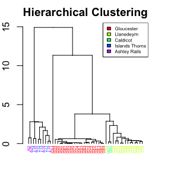

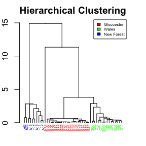

```r
arch_dendro(df_chem = df_chem, df_raw = df_raw, printDendro = FALSE, nplot=c(2,3))
```

###Principal Component Analysis (PCA)

For the alr transformation, the less variable element is generated in arch_evenness and saved as .lvar. Here “.lvar” is read automatically. nplot: is the vector of plots to be displayed. Chose the index of categorical columns to be displayed. printPCA = TRUE for generating pdf and emf files.

```
#> Too few points to calculate an ellipse
```

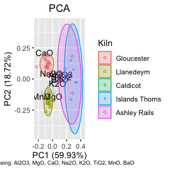

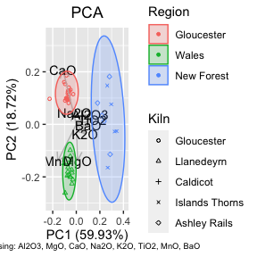

```r
arch_PCA(df_chem, df_raw =df_raw, printPCA= FALSE, labels = FALSE, nplot = c(2,3), shape_cat_number = 2)
```

###Heatmap (table with the concentrations)

```r
#arch_heatmap(df_chem)
```

###Ternary Diagram

Estimate SiO2 if not available in the dataset.

```r
SiO2 <- 0
total <- 98


if (!"SiO2" %in% colnames(df_chem) == TRUE)  {

      SiO2 <- 1

      df_chem$SiO2 <- c(rep(0, nrow(df_chem)))

  for (i in 1:nrow(df_chem)){

      df_chem$SiO2[i] <- total - sum(df_chem[i,])

      }

cbind(df_raw[,c(1:3)], df_chem) -> df_raw

}
```

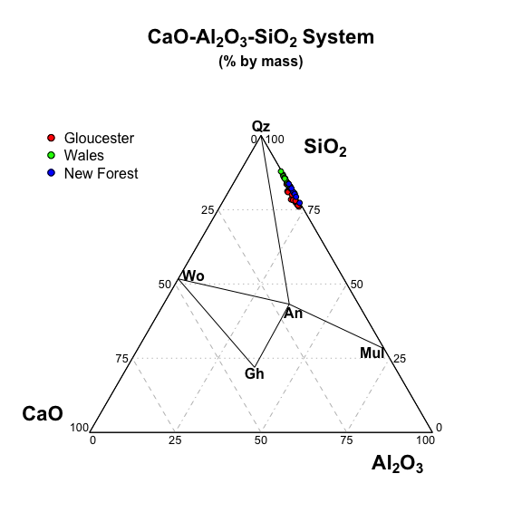

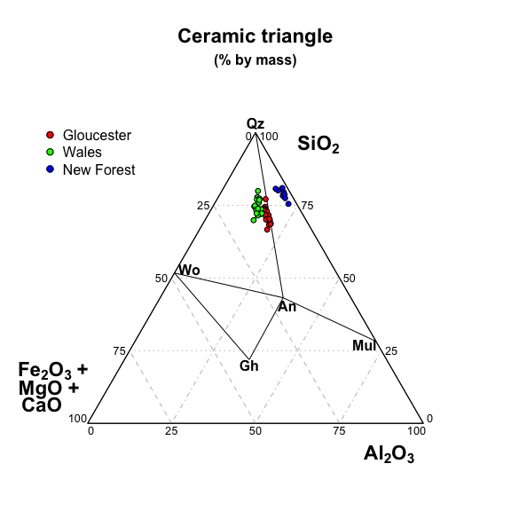

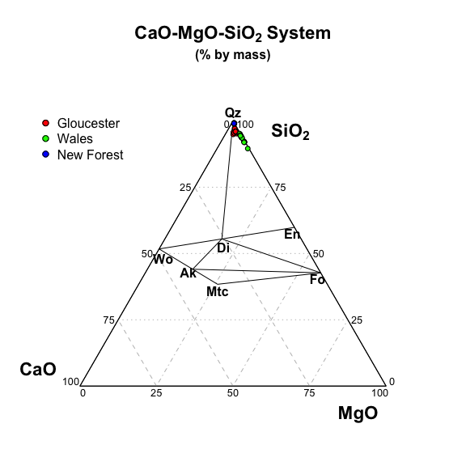

```r
arch_triangles(df_raw, plot.category = 3, rounded_circle = ) #grup = indicates the column from which the factors will be for the legend
```

```r
#Remove the column of estimated SiO2
if (SiO2 == 1){
  df_chem[,-c(ncol(df_chem))] -> df_chem
  df_raw[,-c(ncol(df_raw))] -> df_raw
  SiO2 <- 0
}
```

###Final Remarks

```
#> This is the first step of the ArchFlow workflow
```

## Styles

```
output:
  rmarkdown::html_vignette:
    css: mystyles.css
```

## Figures

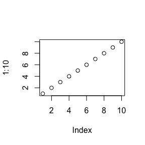

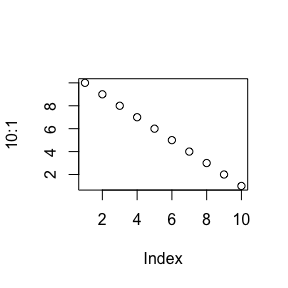

```r
plot(1:10)
plot(10:1)
```

You can enable figure captions by `fig_caption: yes` in YAML:

```
output:
  rmarkdown::html_vignette:
    fig_caption: yes
```

Then you can use the chunk option `fig.cap = "Your figure caption."` in **knitr**.

## More Examples

You can write math expressions, e.g. $Y = X\beta + \epsilon$, footnotes[^1], and tables, e.g. using `knitr::kable()`.

|  | mpg | cyl | disp | hp | drat | wt | qsec | vs | am | gear | carb |
| --- | --- | --- | --- | --- | --- | --- | --- | --- | --- | --- | --- |
| Mazda RX4 | 21.0 | 6 | 160.0 | 110 | 3.90 | 2.620 | 16.46 | 0 | 1 | 4 | 4 |
| Mazda RX4 Wag | 21.0 | 6 | 160.0 | 110 | 3.90 | 2.875 | 17.02 | 0 | 1 | 4 | 4 |
| Datsun 710 | 22.8 | 4 | 108.0 | 93 | 3.85 | 2.320 | 18.61 | 1 | 1 | 4 | 1 |
| Hornet 4 Drive | 21.4 | 6 | 258.0 | 110 | 3.08 | 3.215 | 19.44 | 1 | 0 | 3 | 1 |
| Hornet Sportabout | 18.7 | 8 | 360.0 | 175 | 3.15 | 3.440 | 17.02 | 0 | 0 | 3 | 2 |
| Valiant | 18.1 | 6 | 225.0 | 105 | 2.76 | 3.460 | 20.22 | 1 | 0 | 3 | 1 |
| Duster 360 | 14.3 | 8 | 360.0 | 245 | 3.21 | 3.570 | 15.84 | 0 | 0 | 3 | 4 |
| Merc 240D | 24.4 | 4 | 146.7 | 62 | 3.69 | 3.190 | 20.00 | 1 | 0 | 4 | 2 |
| Merc 230 | 22.8 | 4 | 140.8 | 95 | 3.92 | 3.150 | 22.90 | 1 | 0 | 4 | 2 |
| Merc 280 | 19.2 | 6 | 167.6 | 123 | 3.92 | 3.440 | 18.30 | 1 | 0 | 4 | 4 |

Also a quote using `>`:

> “He who gives up [code] safety for [code] speed deserves neither.” ([via](https://twitter.com/hadleywickham/status/504368538874703872))
[^1]: A footnote here.